# Analiza datasetu - cechy

Joanna Gajewska & Olaf Werner & Bogdan Jastrzębski

April 14, 2019

# 1. Wstępna analiza zbioru danych

W tej części znajduje się przeprowadzona przez nas analiza dostępnego zbioru danych. Zinterpretowaliśmy cechy rekordów, ich znaczenie, a także rozmaite flagi wykorzystane przez autorów, do oznaczania braków, nieścisłości etc.

## 1.1 Flagi

W danych pojawiają się następujące flagi:

- -9 - brak zapisu biurowego lub brak prześledzenia
- -8 - brak użytecznych/ważnych kredytów lub recenzji kredytu
- -7 - warunek niespełniony

`-9` oznacza zwykły brak danych, brak zapisu o czymś. Zwykle kiedy w rekordzie pojawiała się flaga `-9`, pojawiała się we wszystkich kolumnach rekordu. Takich rekordów było 558 na 10 459 wszystkich rekordów datasetu. Te rekordy *usunęliśmy*.

Flaga `-7` pojawiała się wtedy, gdy dla danego kredytobiorcy danych nie da się logicznie uzupełnić, np. jeżeli dana kolumna podaje czas od ostatniego spóźnienia w spłacaniu kredytu, podczas gdy kredytobiorca nie spóźnił się ani razu. Z oczywistych względów mierzenie czasu, który upłynął od zdarzenia, które nie zaszło, jest nielogiczne.

## 1.2 Flagi - krótkie zestawienie

Oto jak przedstawia się udział poszczególnych flag w różnych kolumnach:

| Nazwa kolumny | *-9* | *-8* | *-7* |
| --- | --- | --- | --- |
| ExternalRiskEstimate | 10 | 0 | 0 |
| MSinceOldestTradeOpen | 0 | 239 | 0 |
| MSinceMostRecentDelq | 0 | 176 | 4664 |
| MSinceMostRecentInqexcl7days | 0 | 476 | 1855 |
| NetFractionRevolvingBurden | 0 | 186 | 0 |
| NetFractionInstallBurden | 0 | 3419 | 0 |
| NumRevolvingTradesWBalance | 0 | 156 | 0 |
| NumInstallTradesWBalance | 0 | 861 | 0 |
| NumBank2NatlTradesWHighUtilization | 0 | 583 | 0 |
| PercentTradesWBalance | 0 | 18 | 0 |

Jak widać przeciętnie dane występują w małej liczności w stosunku do wielkości zbioru danych (10 459), jednak kilka kolumn zawiera flag bardzo dużo. W sumie wierszy bez flag `-9`, `-8` i `-7` jest 2502, czyli zaledwie $\frac{1}{4}$ zbioru.

## 1.3 Interpretacja i analiza cech

### Risk Performance

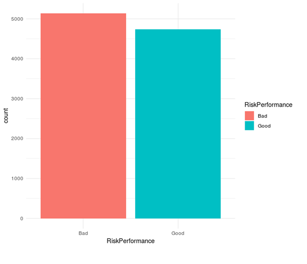

Zbiór wartości: {Good, Bad}

- -9 : 0
- -8 : 0
- -7 : 0

Czy zapłacono w terminie umowy? (12-36 miesięcy)

Watrość przez nas przewidywana. Odpowiada na pytanie, czy klient spłacił kredyt w wyznaczonym terminie.

### External Risk Estimate

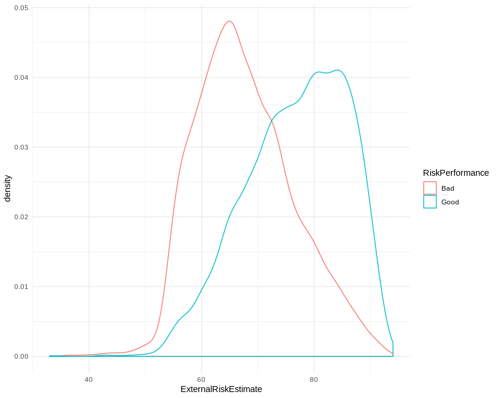

Zbiór wartości: 0-100%

Zewnętrzna ocena kredytobiorcy. Złożenie wielu nieznananych znaczników, działających na korzyść bądź niekorzyść kredytobiorcy.

### Months Since Oldest Trade Open

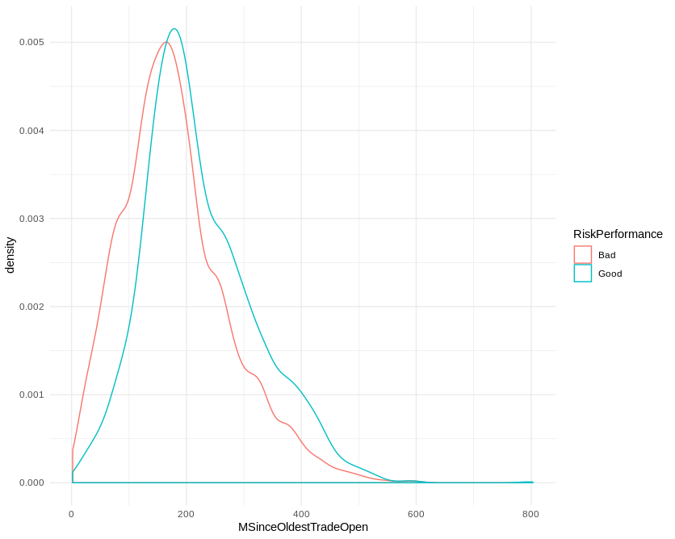

- -9 : 0
- -8 : 239
- -7 : 0

Liczba miesięcy od otwarcia najstarszego kredytu.

### Months Since Most Recent Trade Open

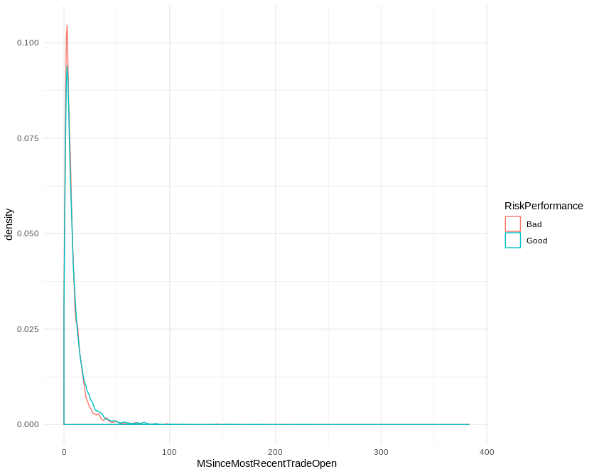

Zbiór wartości: 0, 1, 2, 3…

Liczba miesięcy od otwarcia ostatniego kredytu.

### Average Months in File

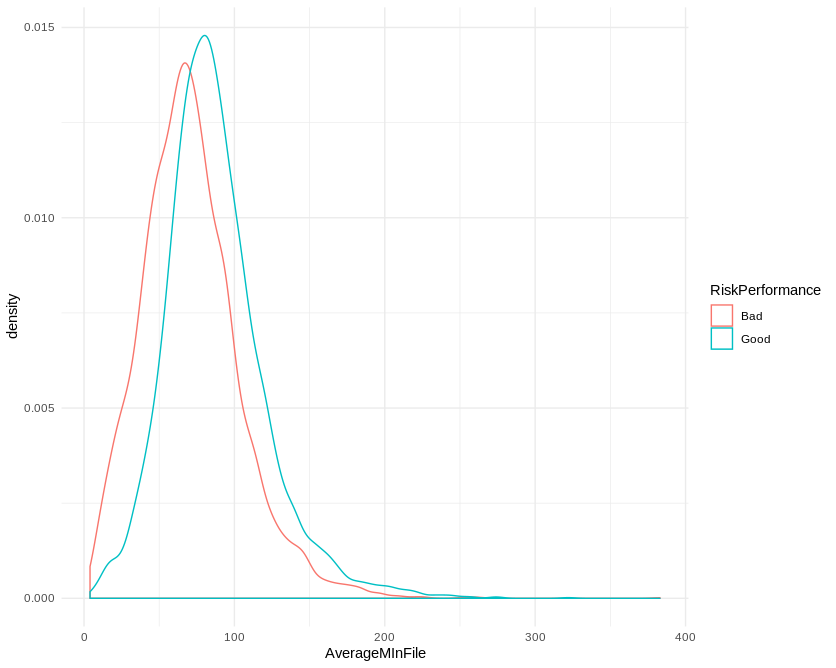

Zbiór wartości: 0, 1, 2, 3…

- -9 : 0
- -8 : 0
- -7 : 0

Średni czas zadłużenia.

### Number Satisfactory Trades

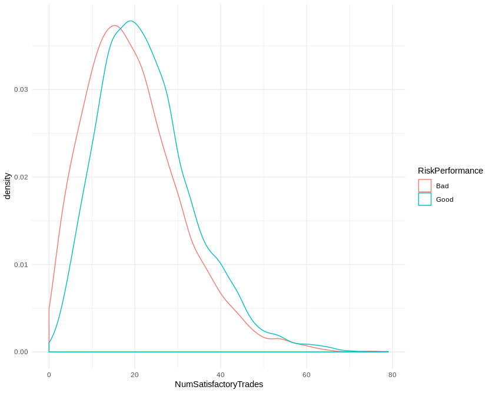

Zbiór wartości: $\mathcal{R}_+$

- -9 : 0
- -8 : 0
- -7 : 0

Liczba spłaconych kredytów.

### Number Trades 60+ Ever

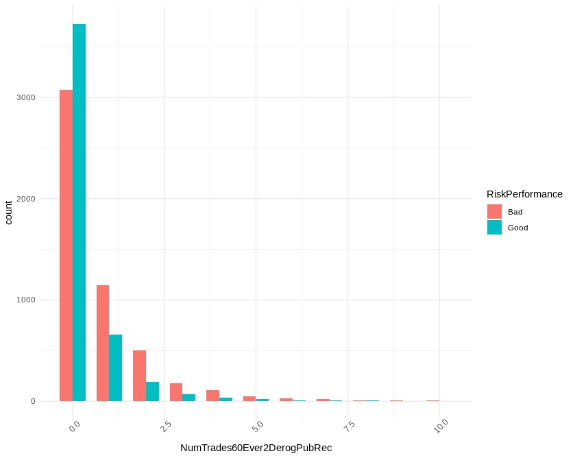

Zbiór wartości: $\mathcal{R}_+$

- -9 : 0
- -8 : 0
- -7 : 0

Liczba kredytów ponad 60 tys.

### Number Trades 90+ Ever

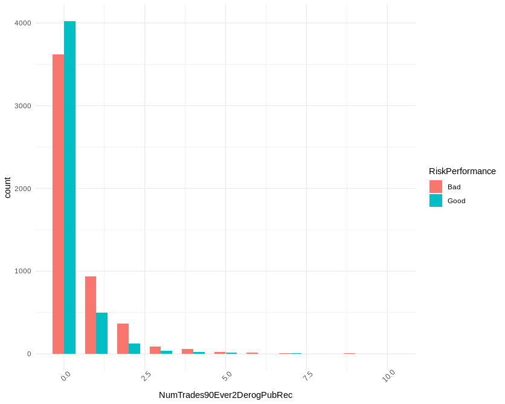

Zbiór wartości: 0, 1, 2, 3…

- -9 : 0
- -8 : 0
- -7 : 0

Liczba kredytów ponad 90 tys.

### Percent Trades Never Delinquent

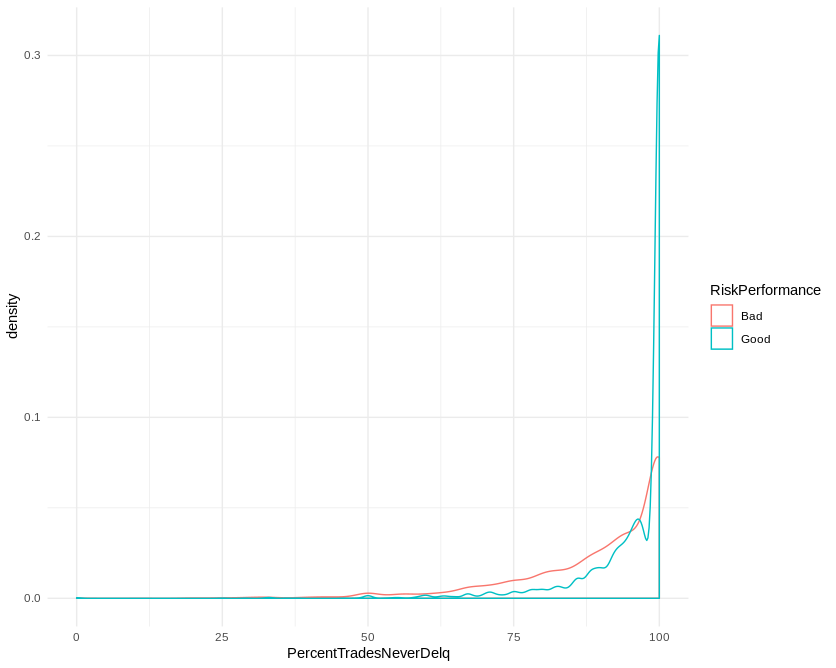

Zbiór wartości: 0-100%

- -9 : 0
- -8 : 0
- -7 : 0

Procent kredytów nigdy niezaległych.

### Months Since Most Recent Delinquency

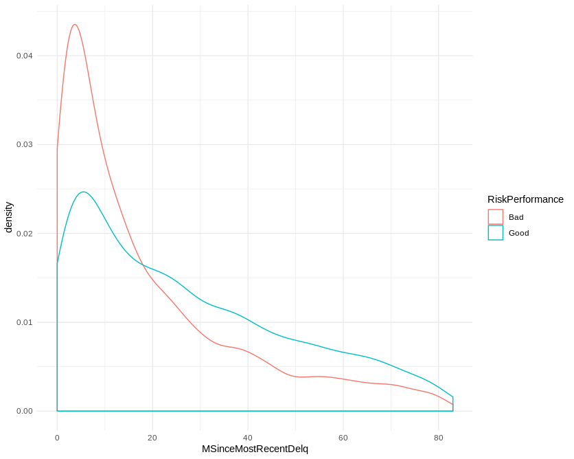

Zbiór wartości: 0, 1, 2, 3…

- -9 : 0
- -8 : 176
- -7 : 4664

Liczba miesięcy od ostatniego opóźnienia.

### Number Total Trades

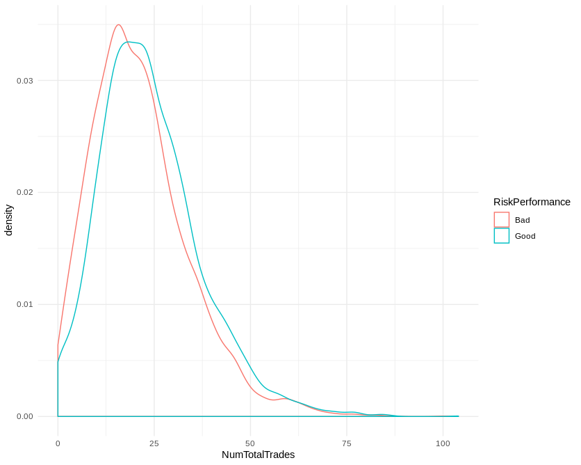

Zbiór wartości: 0, 1, 2, 3…

- -9 : 0
- -8 : 0
- -7 : 0

Całkowita liczba kredytów lub inaczej liczba kont kredytowych.

### Number Trades Open in Last 12 Months

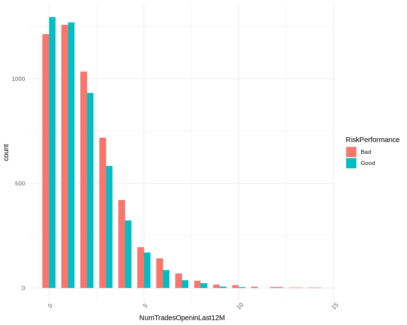

Zbiór wartości: 0, 1, 2, 3…

- -9 : 0
- -8 : 0
- -7 : 0

Liczba kredytów zaciągniętych podczas ostatnich dwunastu miesięcy.

### Percent Installment Trades

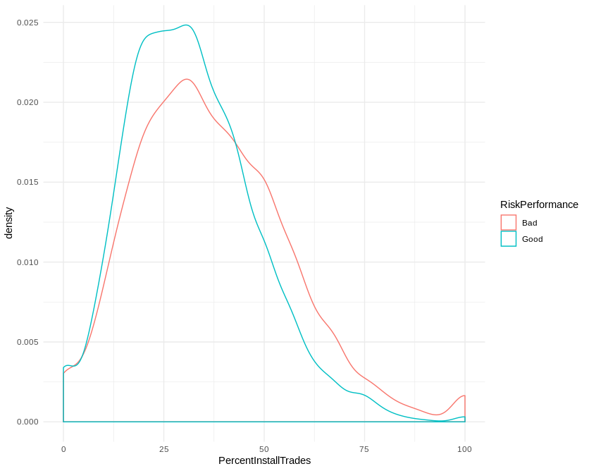

Zbiór wartości: 0-100%

- -9 : 0
- -8 : 0
- -7 : 0

Odsetek kredytów, które były ratalne tj. spłacane w ratach.

### Months Since Most Recent Inq. Excl. 7 days

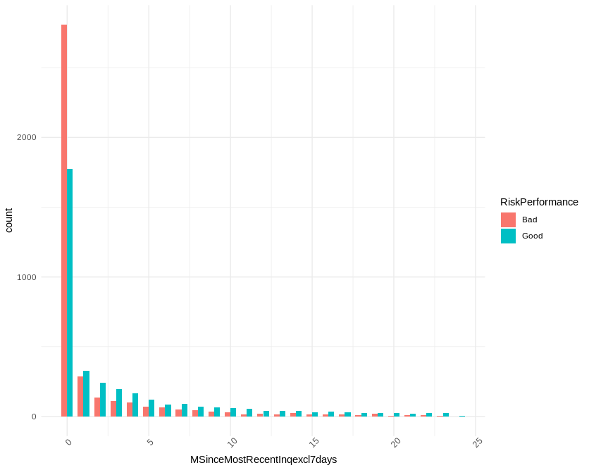

Zbiór wartości: 0, 1, 2, 3…

- -9 : 0
- -8 : 476
- -7 : 1855

Liczba miesięcy od ostatniego sprawdzenia kredytu (przekraczające 7 dni).

### Number Inq. Last 6 Months

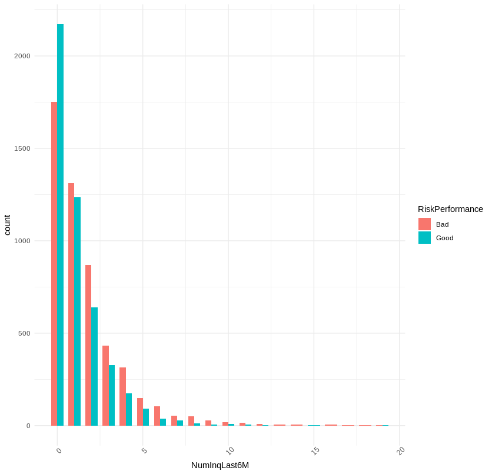

Zbiór wartości: 0, 1, 2, 3…

- -9 : 0
- -8 : 0
- -7 : 0

Liczba sprawdzeń kredytu podczas ostatnich 6 miesięcy.

### Number Inq. Last 6 Months excl. 7 days

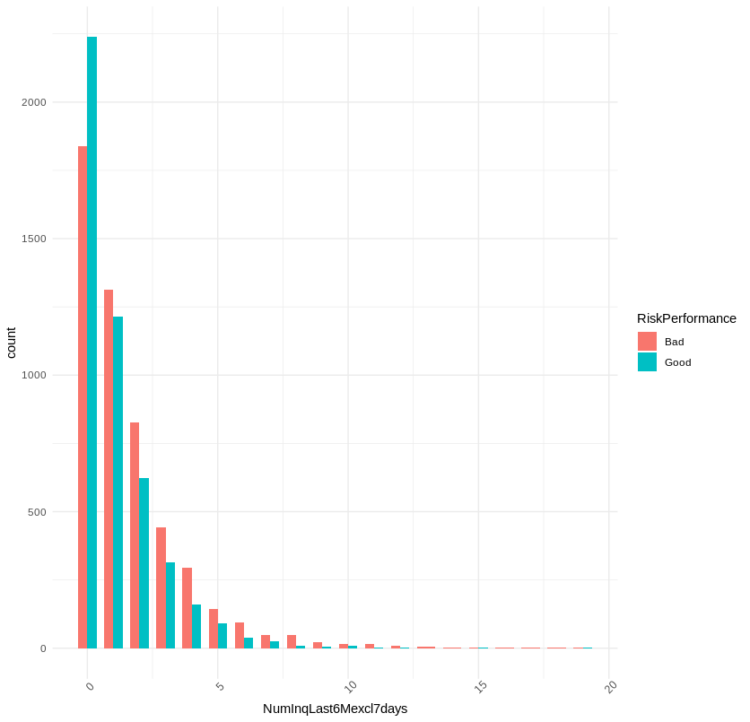

Zbiór wartości: 0, 1, 2, 3…

- -9 : 0
- -8 : 0
- -7 : 0

Liczba sprawdzeń kredtu przekaraczających 7 dni.

### Net Fraction Revolving Burden

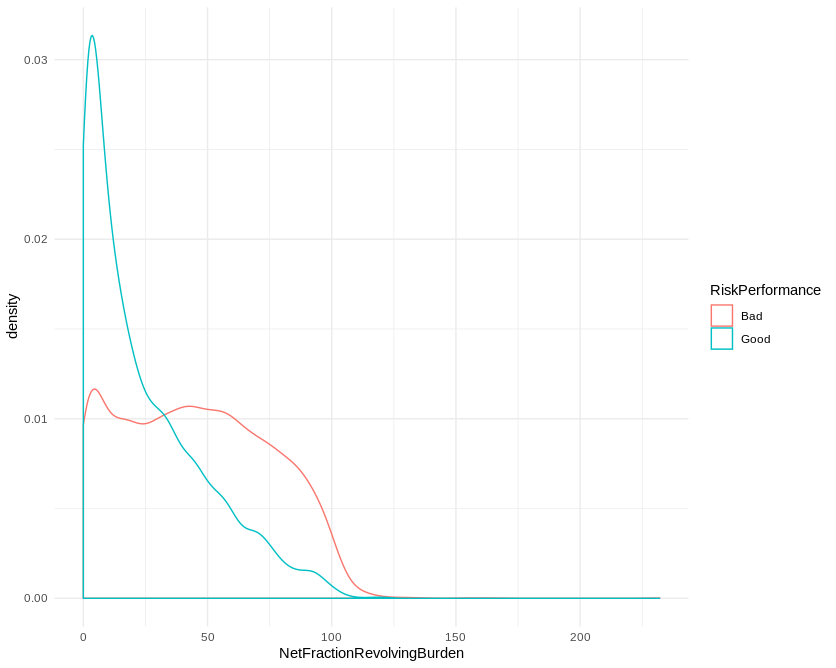

Zbiór wartości: 0, 1, 2, 3…

- -9 : 0
- -8 : 186
- -7 : 0

Udział kredytów rolowanych w obciążeniu kredytowym.

### Net Fraction Installment Burden

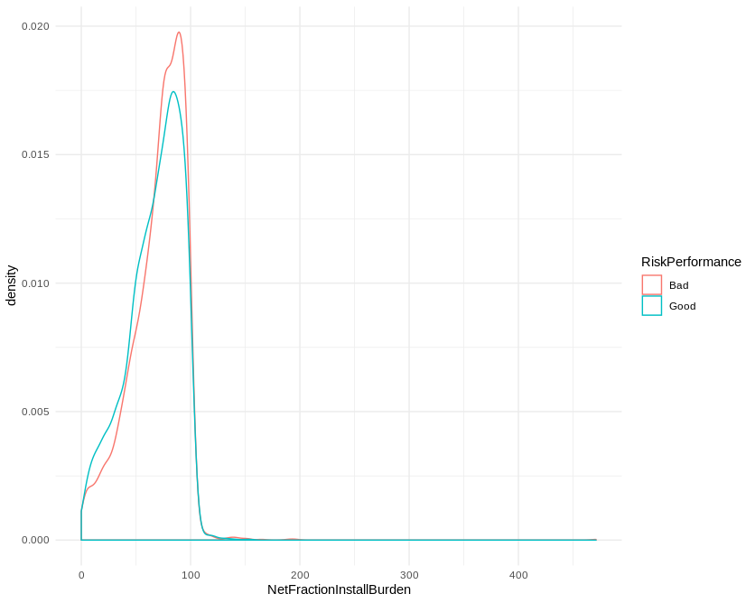

Zbiór wartości: 0, 1, 2, 3…

- -9 : 0
- -8 : 3419
- -7 : 0

Udział kredytów ratalnych w obciążeniu kredytowym.

### Number of Revolving Trades With Balance

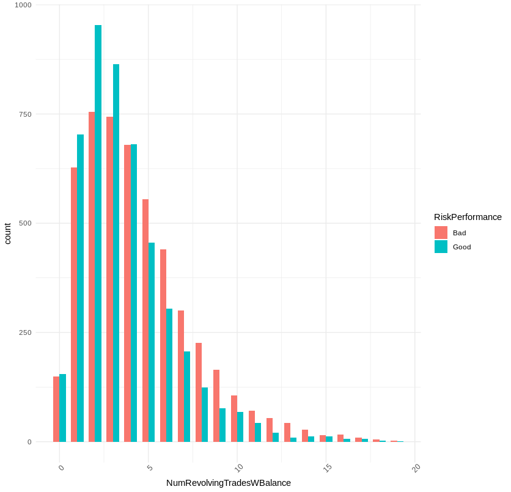

Zbiór wartości: 0, 1, 2, 3…

- -9 : 0
- -8 : 156
- -7 : 0

Liczba kredytów rolowanych z “balonem”, czyli ostateczną dużą spłatą. Oczywiście kredytów rolowanych się często wcale nie spłaca, ewentualnie np. kiedy bank uzna, że ryzyko jest zbyt duże, by przedłużać kredyt dalej.

### Number of Installment Trades With Balance

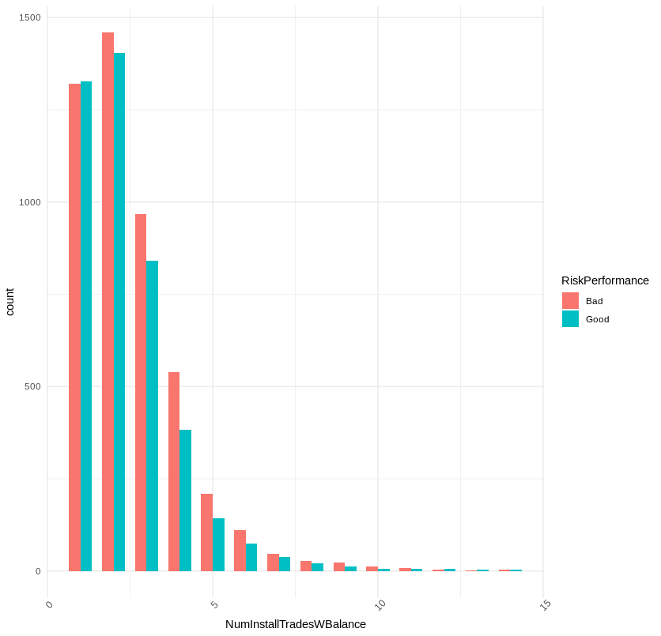

Zbiór wartości: 0, 1, 2, 3…

- -9 : 0
- -8 : 861
- -7 : 0

Liczba kredytów ratalnych ze zbalansowaniem pod koniec, jak wyżej.

### NumBank2NatlTradesWHighUtilization

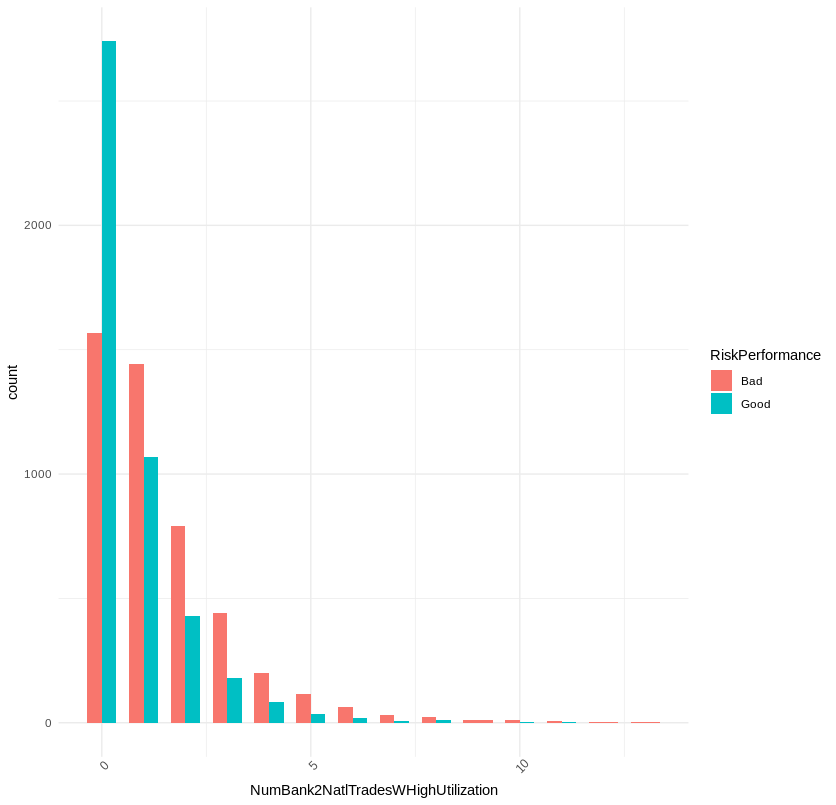

Zbiór wartości: 0, 1, 2, 3…

- -9 : 0
- -8 : 583
- -7 : 0

Liczba kredytów o dużym zysku.

### Percent of Trades With Balance

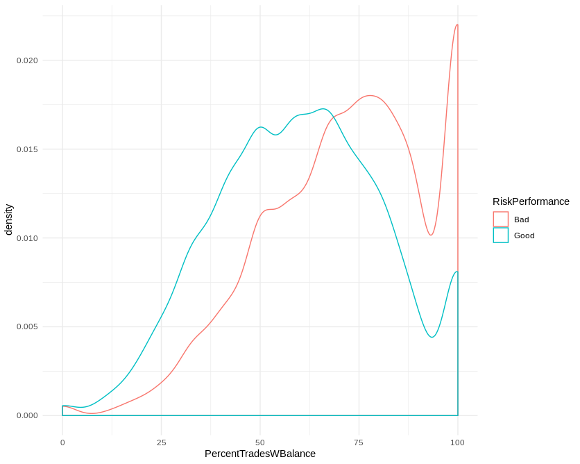

Zbiór wartości: 0-100%

- -9 : 0
- -8 : 18
- -7 : 0

Procent kredytów zbalansowanych, z “balonem”.